# RNA-seq数据GSEA富集分析

分子细胞科学卓越创新中心生物信息平台

10 June 2020

#### Abstract

本文描述了bulk RNA-seq分析流程中GSEA富集子模块，该模块可以得到排序基因列表在基因集中的富集情况，可用来评估特定的基因集与表型或处理之间的关联性。该模块用R语言编写。

# 1 分析流程示意图

该模块需要输入两方面的信息，利用差异基因和特定的功能基因集来完成GESA(Gene Set Enrichment Analysis)<sup>1</sup>的分析。基因集可以自行提供，也可以从[MSigDB](https://www.gsea-msigdb.org/gsea/msigdb/index.jsp)网站下载。差异基因使用来自于DiffExpGenes模块生成的*DESeq2.txt文件，如下图所示。

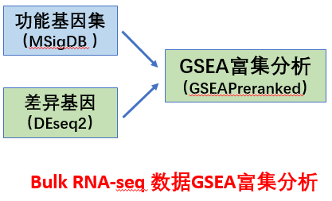

# 2 输出

## 2.1 GSEA 报告

当GSEA分析完成后会在目录下生成一系列的网页报告和对应的Excel表格，以及网页报告的配置文件、运行的日志文件。打开结果文件夹中的index.html网页报告，这是GESA分析结果的总结报告，报告中展现了基因集与表现或处理的关联情况、数据集的概况、基因集概况等信息，具体内容可点击报告中的链接查看。报告内容如下图所示。

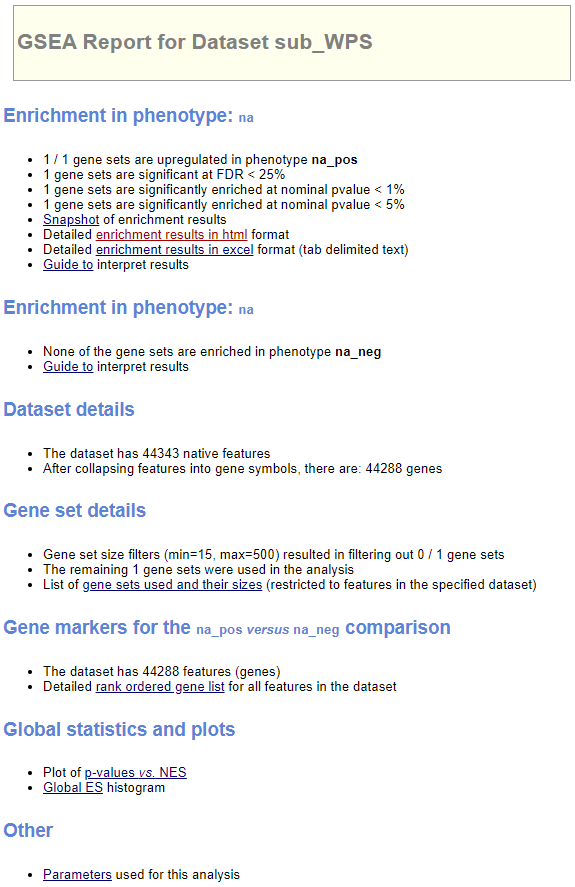

## 2.2 GSEA 富集图

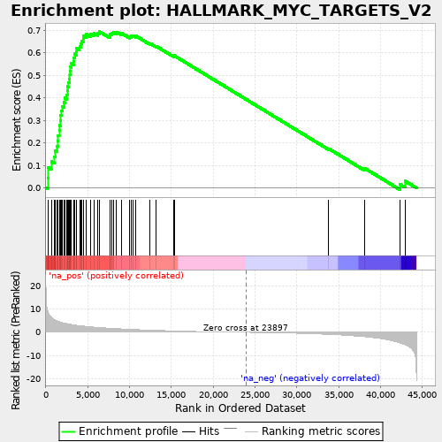

## 2.3 GSEA 富集NES表格

GSEA结果文件夹中“gsea_report_for*.xls”是数据集与某个基因集的富集表格，或者点击index.html报告中的“enrichment results in html”查看网页报告。这里面列出了富集到某个表型的所有基因集，按照normalized enrichment score (NES)排序，如下图所示：

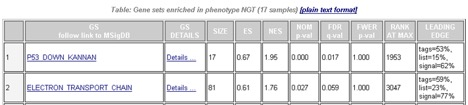

注：
GS：基因集名称，点击会跳转到MSigDB网页；
GS DETAILS：点击会跳转到基因集的详细分析结果；
SIZE：基因集中基因的数目；
ES：富集分数(Enrichment score)；
NES：标准化的ES(Normalized enrichment score)，可用于不同基因集间比较；
NOM p-val：ES的统计学显著性值；
FDR q-val：NES出现一个假阳性的概率；
FWER p-val：NES出现一个假阳性的FWER概率(Familywise-error rate，一个更保守估计的概率)；
RANK AT MAX：排序基因列表中ES最大值的位置；
LEADING EDGE：tags 是Enrichment score折线图中的峰之前（正 ES）或之后（负 ES）基因集中 的基因占基因集总数的百分比；list 是Enrichment score折线图中的峰之前（正 ES）或之后（负 ES）排序基因列表中的基因占排序基因列表基因总数的百分比；signal 是富集信号强度，由前 两项根据以下公式：
$$\left(tags\%\right) * \left(1-Gene\%\right) * \left(\frac{N}{N-Nh}\right)$$
计算得到，其中 N 为排序基因列表中的基因数目，Nh 为基因集中的基因数目。

其他：更多的文件描述见FileDescription。

# 3 参考文献

- [1] Aravind Subramanian, Pablo Tamayo, Vamsi K Mootha,et al. Subramanian, A. et al. Gene set enrichment analysis: a knowledge-based approach for interpreting genome-wide expression profiles. Proceedings of the National Academy of Sciences, 2005, 102(43):15545-15550.